##### Студент: Калугина Дарья

##### Группа: РИ-450004

## Лабораторная работа № 1

## Исходные данные

Экспоненциальное распределение определяется следующей функцией распределения:

```
F(x) = 1 - e^(-λ⋅x)
```

Функция `rexp` генерирует случайные переменные при помощи экспоненциального распределения `rexp(n=42, rate=5)` вернёт 42 экспоненциально-распределённых числа с параметром (λ) равным 5. Ели второй аргумент не указан, будет использовано значение 1 т.е. получим “стандартное экспоненциальное распределение”.

## Задание 1

1. Сгенерируйте 200 случайных значений из стандартного экспоненциального распределения и сохраните в вектор *exp.1*. Найдите среднее и стандартное отклонение из данных этого вектора.

```r
exp.1 <- rexp(n=200)
exp.1_mean <- mean(exp.1) #среднее арифметическое значение элементов вектора exp.1
exp.1_std <- sd(exp.1) # стандартное отклонение
exp.1_std1 <- sqrt(var(exp.1))
```

2. Повторите, использовав следующие значения параметра λ: 0.1, 0.5, 5, 10, и сохраните результаты в векторы: *exp.0.1*, *exp.0.5*, *exp.5*, *exp.10*.

```r
exp.0.1 <- rexp(n=200, rate = 0.1)
exp.0.1_mean <- mean(exp.0.1)
exp.0.1_std <- sd(exp.0.1)

exp.0.5 <- rexp(n=200, rate = 0.5)
exp.0.5_mean <- mean(exp.0.5)
exp.0.5_std <- sd(exp.0.5)

exp.5 <- rexp(n=200, rate = 5)
exp.5_mean <- mean(exp.5)
exp.5_std <- sd(exp.5)

exp.10 <- rexp(n=200, rate = 10)
exp.10_mean <- mean(exp.10)
exp.10_std <- sd(exp.10)
```

Создадим сводную таблицу вычисленных значений:

```r
std_values <- c(exp.1_std, exp.0.1_std, exp.0.5_std, exp.5_std, exp.10_std)
mean_values <- c(exp.1_mean, exp.0.1_mean, exp.0.5_mean, exp.5_mean, exp.10_mean)
vectors <- c("exp.1", "exp.0.1", "exp.0.5", "exp.5","exp.10")
table <- data.frame("Вектор"=vectors,"Среднее_значение"=mean_values, "Стандартное_отклонение"=std_values)
```

| Вектор | Среднее_значение | Стандартное_отклонение |
| --- | --- | --- |
| exp.1 | 0.9420011 | 0.9000926 |
| exp.0.1 | 10.2389749 | 9.6310945 |
| exp.0.5 | 2.1018366 | 1.9719219 |
| exp.5 | 0.2086193 | 0.2224031 |
| exp.10 | 0.0865432 | 0.0852814 |

Результаты вычисления показывают, что при увеличении параметра экспоненциального распределения уменьшается среднее значение и стандартное отклонение элементов векторов от среднего значение (т.е. уменьшается разброс возможных значений случайной величины).

3. Функция `plot()` общая функция для визуализации данных. Функция `hist()` принимает данные и раскладывает их по корзинам. Чтобы использовать эти функции нужно для начала передать им данные, которые хотим визуализировать.
4. Используйте функцию `hist()` для построения гистограммы полученного ранее стандартного распределения.

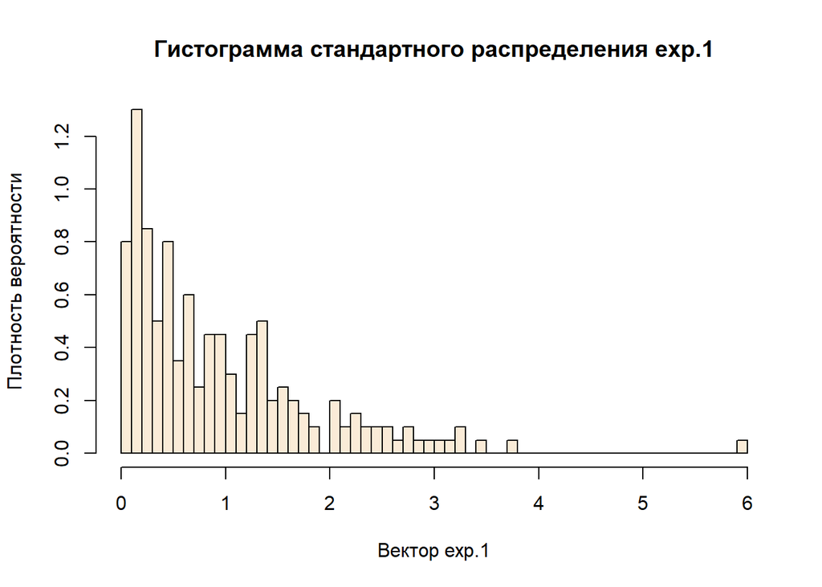

```r
  hist(exp.1, breaks = 60, col="antiquewhite", ylab="Плотность вероятности", xlab="Вектор exp.1", main="Гистограмма стандартного распределения exp.1", freq = FALSE)
```

Для сравнения векторов с разными параметрами распределения построим гистограмму распределения *exp.0.5* с параметром *0.5* и *exp.5* с параметром *5*:

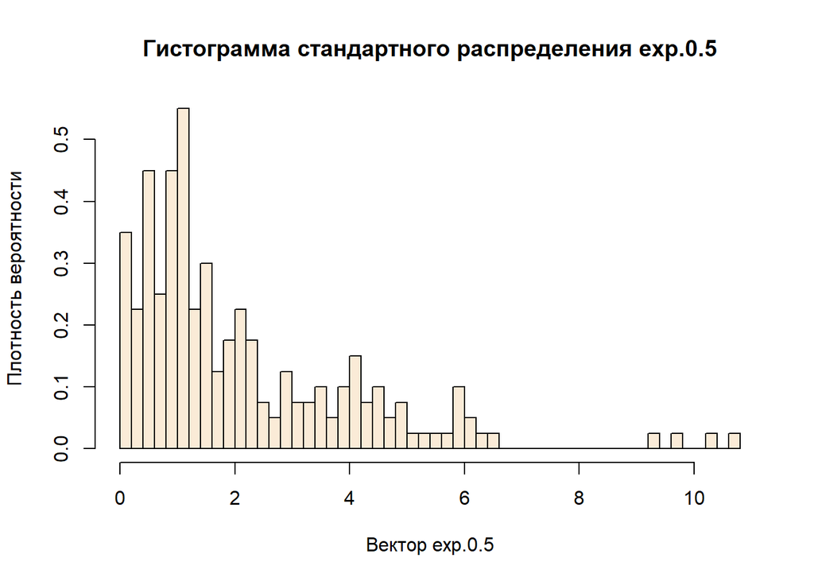

```r
  hist(exp.0.5, breaks = 60, col="antiquewhite", ylab="Плотность вероятности", xlab="Вектор exp.0.5", main="Гистограмма стандартного распределения exp.0.5", freq = FALSE)
```

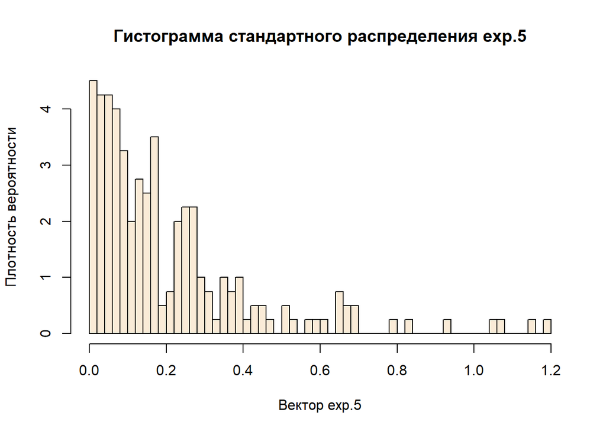

```r
  hist(exp.5, breaks = 60, col="antiquewhite", ylab="Плотность вероятности", xlab="Вектор exp.5", main="Гистограмма стандартного распределения exp.5", freq = FALSE)
```

Из полученных выше диаграмм видно, что при уменьшении параметра распределения уменьшается максимально возможное значение функции плотности вероятности и увеличивается диапазон значений, которые может принять случайная величина, а значит и увеличивается величина стандартного отклонения. При увеличении параметра, наоборот, уменьшается разброс значений случайной величины относительно среднего значения, возрастает максимум функции плотности (график “прижимается” к оси ординат и все большее количество принимаемых случайной величиной значений располагается ближе к началу координат).

5. Используйте функцию `plot()` с тем же самым вектором для построения графика значений в порядке следования

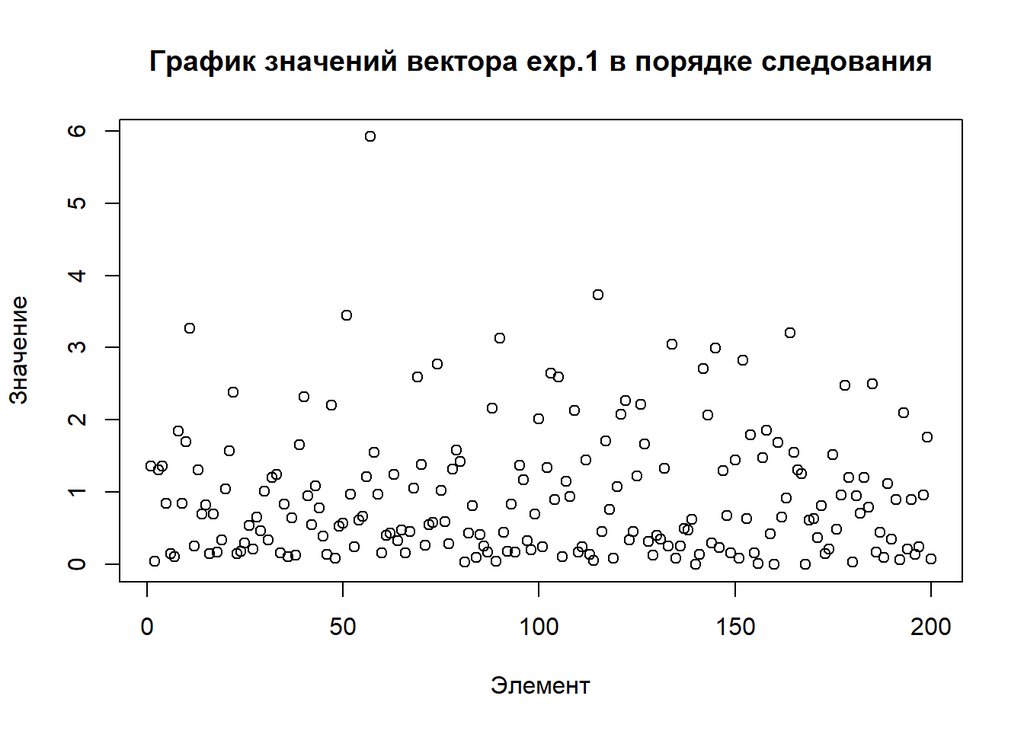

```r
plot(exp.1, xlab="Элемент", ylab="Значение", main="График значений вектора exp.1 в порядке следования")
```

6. Используйте функцию `plot()` с любыми двумя полученными ранее векторами, чтобы получить диаграмму рассеяния ([scatterplot](https://www.mathsisfun.com/data/scatter-xy-plots.html)) этих векторов относительно друг друга.

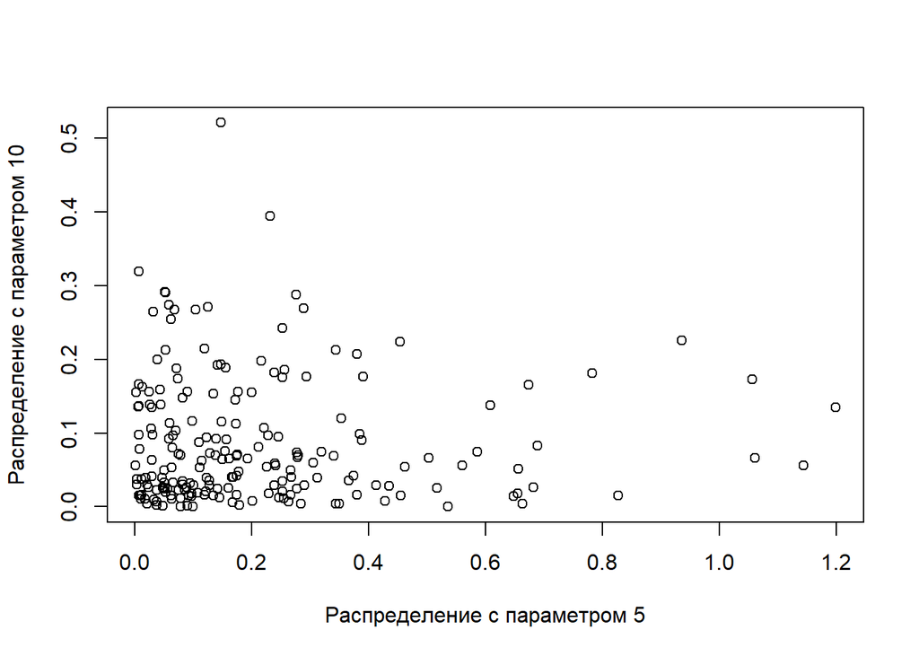

```r
plot(exp.5, exp.10, xlab = "Распределение с параметром 5", ylab = "Распределение с параметром 10")
```

Построенная диаграмма рассеяния элементов вектора с параметром распределения, равным 10, относительно элементов вектора с параметром, равным 5, показывает, что элементы вектора с меньшим значением параметра принимают значения из более широкого интервала, и наоборот. При этом после достижения определенного значения плотности вероятности распределение с параметром 10 начинает быстрее убывать (т.е. график плотности вероятности быстрее “прижимается” к оси абсцисс и значение функции быстрее стремится к нулю). Например, в то время как случайная величина с параметром распределения 5 принимает значения на интервале *(0.6, 0.8)*, значение случайной величины, соответствующее параметру 10, не выходит за пределы интервала *(0, 0.2)*.

7. Теперь сравним свойства всех наших векторов. Для начала создадим вектор *exp.means*, содержащий средние значения каждого из 5 полученных ранее распределений в порядке их создания.

```r
exp.means <- c(exp.1_mean, exp.0.1_mean, exp.0.5_mean, exp.5_mean, exp.10_mean)
```

Далее необходимо создать следующие диаграммы рассеяния:

- Вектор с пятью средними относительно каждого из пяти векторов с различными значениями λ.

```r
lambda <- c(1,0.1,0.5,5,10)
```

**Диаграмма рассеяния вектора средних значений относительно вектора значений параметра распределения:**

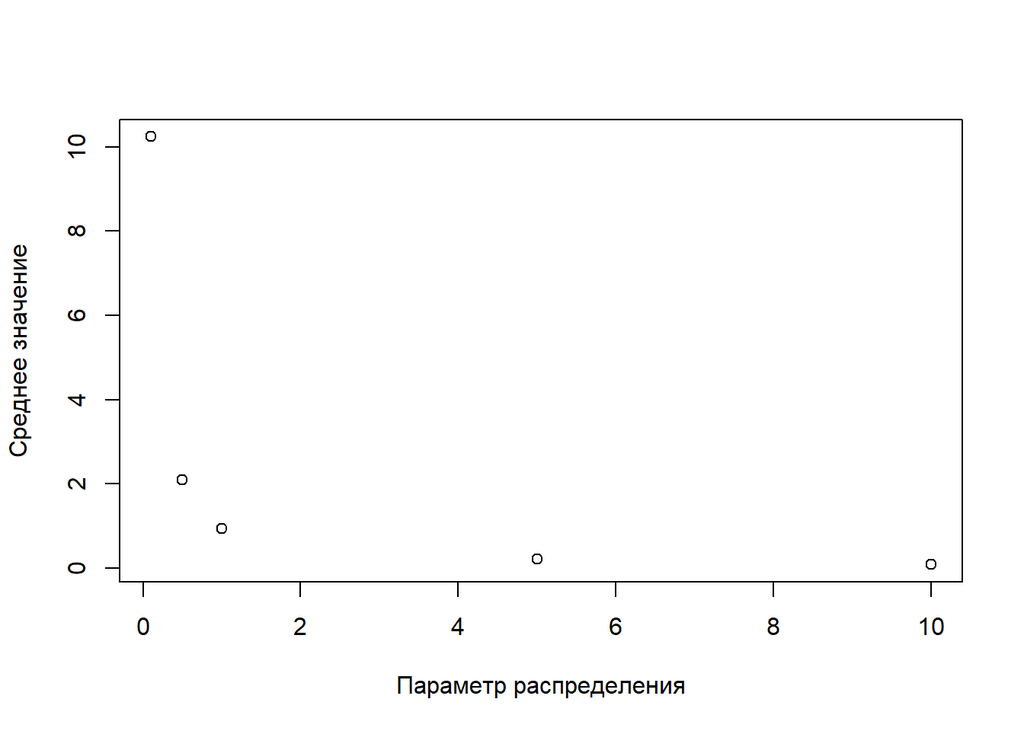

```r
plot(lambda, exp.means, xlab = "Параметр распределения", ylab = "Среднее значение")
```

При увеличении параметра распределения уменьшается среднее значение элементов выборок, т.к. “сужается” интервал значений, которые могут принимать элементы.

- Вектор с пятью стандартными отклонениями относительно каждого из пяти векторов с различными значениями λ.

**Диаграмма рассеяния вектора стандартных отклонений относительно вектора значений параметра распределения:**

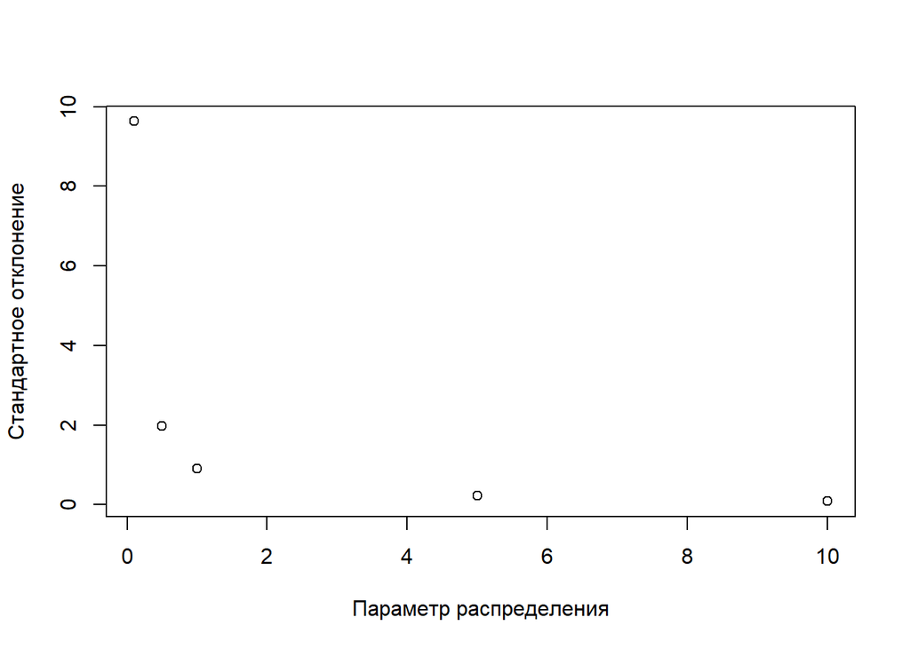

```r
exp.std <- c(exp.1_std, exp.0.1_std, exp.0.5_std, exp.5_std, exp.10_std)
plot(lambda, exp.std, xlab = "Параметр распределения", ylab = "Стандартное отклонение")
```

Построенная выше диаграмма рассеяния показывает, что меньшему значению параметра распределения соответствует большее значение стандартного отклонения (больший разброс возможных значений случайной величины).

- Вектор с пятью средними относительно вектора с пятью стандартными отклонениями.

**Диаграмма рассеяния вектора средних значений относительно вектора стандартных отклонений:**

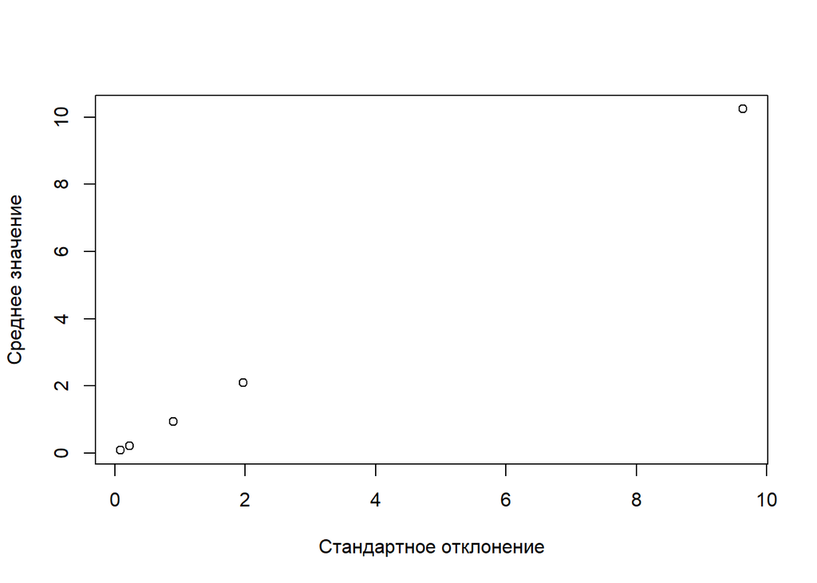

```r
plot(exp.std, exp.means, xlab = "Стандартное отклонение", ylab = "Среднее значение")
```

Зависимость между средним значением элементов распределения и их стандартным отклонением от этого значения является прямой.

## Задание 2

R достаточно производителен, чтобы вычислять относительно большие объёмы данных.

- Для демонстрации сгенерируйте 1100000 (1 млн. 100 тысяч) чисел из стандартного экспоненциального распределения и сохраните их в вектор *huge.exp.1*. Получите среднее и стандартное отклонение.

```r
huge.exp.1 <- rexp(n=1100000)
huge.exp.1_mean <- mean(huge.exp.1)
huge.exp.1_std <- sd(huge.exp.1)
huge.exp.1_mean # среднее арифметическое значение элементов вектора exp.1
```

```
## [1] 0.999335
```

```r
huge.exp.1_std  # стандартное отклонение
```

```
## [1] 1.000474
```

- Получите гистограмму *huge.exp.1*. Она соответствует функции `1 - e:^(-x)`? Должна ли?

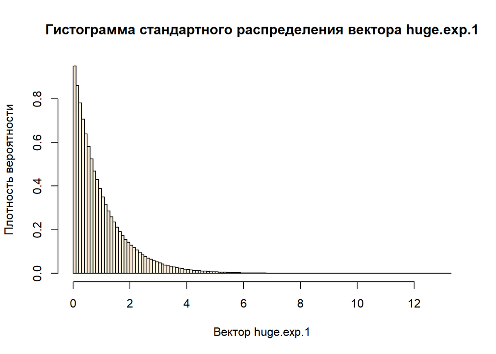

```r
  hist(huge.exp.1, breaks = 100, col="antiquewhite", ylab="Плотность вероятности", xlab="Вектор huge.exp.1", main="Гистограмма стандартного распределения вектора huge.exp.1", freq = FALSE)
```

Полученная диаграмма не соответствует функции `1 - e^(-x)` и не должна ей соответствовать, поскольку данная функция является фукнцией экпоненциального распределения, а на гистограмме отображается функция плотности вероятности (функция экспоненциального распределения получается путем интегрирования функции плотности вероятности).

- Получите среднее всех чисел из *huge.exp.1* строго больших 1. Для проверки выборки может потребоваться новый вектор.

```r
huge.exp.1_more.than.1 <- huge.exp.1[huge.exp.1>1]
mean(huge.exp.1_more.than.1)
```

```
## [1] 2.000046
```

- Получите матрицу *huge.exp.1.mat*, содержащую 1100 строк и 1000 колонок. Постройте гистограмму, использовав полученную матрицу.

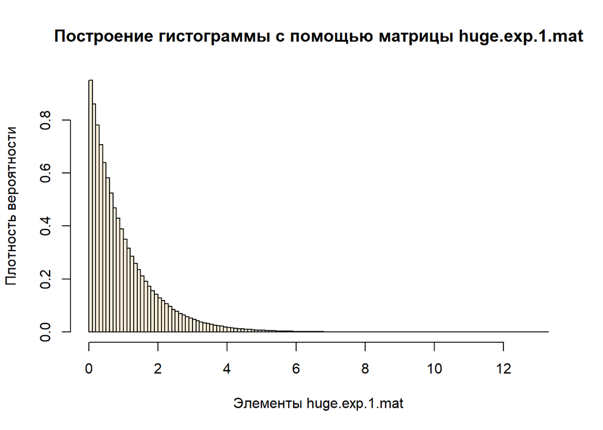

```r
huge.exp.1.mat <- matrix(huge.exp.1, nrow = 1100, ncol = 1000)
hist(huge.exp.1.mat, breaks = 100, col="antiquewhite", ylab="Плотность вероятности", xlab="Элементы huge.exp.1.mat", main="Построение гистограммы с помощью матрицы huge.exp.1.mat", freq = FALSE)
```

- Рассчитайте среднее 137-й колонки из *huge.exp.1.mat*.

```r
col.137.mean <- mean(huge.exp.1.mat[,137])
col.137.mean
```

```
## [1] 0.9694244
```

- Найдите среднее всех 1000 колонок и сохраните их в вектор. Отобразите диаграмму средних значений колонок.

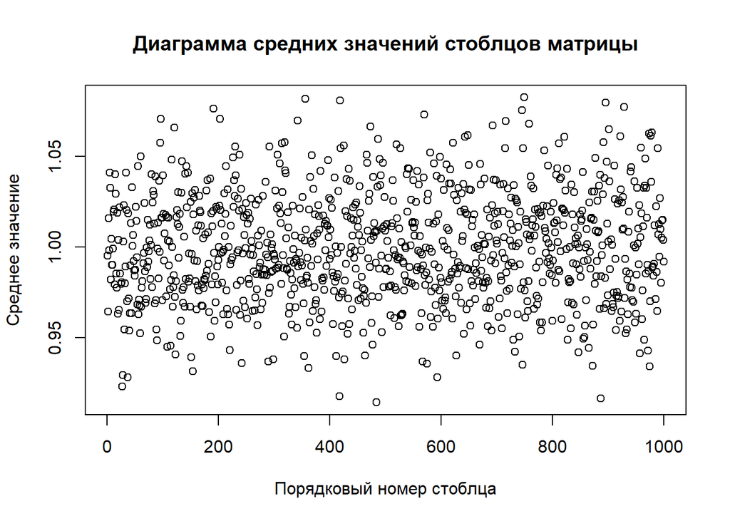

```r
cols.mean <- apply(huge.exp.1.mat, 2, mean)
plot(cols.mean, xlab = "Порядковый номер стоблца", ylab = "Среднее значение", main = "Диаграмма средних значений стоблцов матрицы")
```

Форма диаграммы отличается от построенных ранее, т.к. в данном случае было вычислено среднее значение 1000 векторов (столбцов матрицы *huge.exp.1.mat*), состоящих из 1100 элементов (количество строк матрицы *huge.exp.1.mat*), соответствующих экспоненциальному распределению. Элементы полученного вектора принимают значения, близкие к среднему значению элементов исходного вектора *huge.exp.1*, поэтому на полученной диаграмме большая часть точек сосредоточена вблизи этого значения.

- Рассчитайте квадрат каждого значения из *huge.exp.1* и найдите среднее и стандартное отклонение полученного вектора квадратов.

```r
huge.exp.1.square <- huge.exp.1^2
mean(huge.exp.1.square) # среднее значение вектора квадратов
```

```
## [1] 1.999617
```

```r
sd(huge.exp.1.square)   # стандартное отклонение
```

```
## [1] 4.492402
```

Объясните отличие от соответствующих показателей вектора *huge.exp.1*. Вам может помочь формула, по которой R рассчитывает стандартное отклонение: `sqrt(sum((x-mean(x))^2)/(n-1))`.

В вектор *huge.exp.1.square* были записаны элементы вектора *huge.exp.1*, возведенные в квадрат. Поэтому среднее значение элементов оказалось больше среднего, расчитанного для вектора *huge.exp.1*. При вычислении стандартного отклонения вычислялась разность между квадратом значения и среднего всех значений, возведенных в квадрат. Этим объясняется различие вычисленных статистических характеристик векторов *huge.exp.1* и *huge.exp.1.square*.